# Assigment 7

Jeff Moise

10/16/2019

1. Write a function: input a number x and return x^2+3x+1

```r
func <- function(x) {
  y <- x^2+3*x+1
  return(y)
}

func(1)
```

```
## [1] 5
```

2. Not using loops, write a function: input a vector and return the product of all the entries in the vector.

```r
func <- function(z) {
  prod(z)
}
x <-c(1,3,4)
func(x)
```

```
## [1] 12
```

3. Using loops, write a function: input a vector and return the product of all the entries in the vector.

```r
func <- function(vec) {
  y=1
 for (i in 1:length(vec)){
   y <- y*vec[i]
}
  y
}

func(c(1,2,3))
```

```
## [1] 6
```

4.a the rows sum squares of matrix x above.

```r
x = matrix(c(1:9), nrow=3)
x
```

```
##      [,1] [,2] [,3]
## [1,]    1    4    7
## [2,]    2    5    8
## [3,]    3    6    9
```

```r
apply(x,1,function(x){sum(x^2)})
```

```
## [1]  66  93 126
```

4.b. the row sums of positive entries in y, where y is a 100x100 matrix with the entries following standard normal distribution.

```r
y<- matrix( rnorm(100*100,mean=0,sd=1), 100, 100)

apply(y,1,function(y){sum(y[which(y>0)])})
```

```
##   [1] 38.67594 33.86230 51.24517 39.78249 39.51138 42.47393 32.68085
##   [8] 40.75364 27.25072 36.43289 27.40396 30.14305 26.88100 46.42274
##  [15] 43.74870 44.28537 50.77438 35.33054 43.74038 26.89500 36.09799
##  [22] 44.66000 39.81128 43.23967 55.48562 46.42860 40.44926 29.99790
##  [29] 33.69076 41.25688 40.23484 44.81035 45.86215 50.80011 42.28339
##  [36] 35.38745 32.70574 44.07891 33.84732 33.90381 42.43340 26.75916
##  [43] 47.08816 49.77523 45.80407 42.33943 39.74101 34.02512 39.28618
##  [50] 41.03837 45.96646 38.13709 41.23485 37.20322 43.23401 42.10084
##  [57] 42.80719 36.36808 37.44584 40.99978 31.74024 43.65243 30.72190
##  [64] 50.36575 46.14399 41.19454 36.90327 38.93763 36.64329 44.52925
##  [71] 30.96448 37.16620 41.37450 37.71414 35.98682 30.94508 42.08934
##  [78] 41.63505 39.58312 37.53810 32.34024 43.03573 46.97699 52.43514
##  [85] 36.54362 38.60112 43.32023 37.13965 44.13547 54.24276 20.65102
##  [92] 37.57788 35.84789 43.34538 43.16264 35.44450 40.77672 39.42445
##  [99] 33.71592 23.49888
```

4c. the row sums square of entries in y, where y is a 100x100 matrix with the entries following standard normal distribution. What is the distribution of these sum squares?

```r
y1 <- apply(y,1,function(y){(sum(y)^2)})

df <- data.frame(y1)
df
```

```
##               y1
## 1     26.4310436
## 2     28.2404166
## 3    290.8821327
## 4     13.6161323
## 5      6.2256702
## 6      0.3469113
## 7     93.4437592
## 8      1.0756988
## 9    767.2385030
## 10    17.8070625
## 11   201.3697765
## 12   131.4598787
## 13   381.5861405
## 14   288.2228996
```

[output cut: 86 more lines]

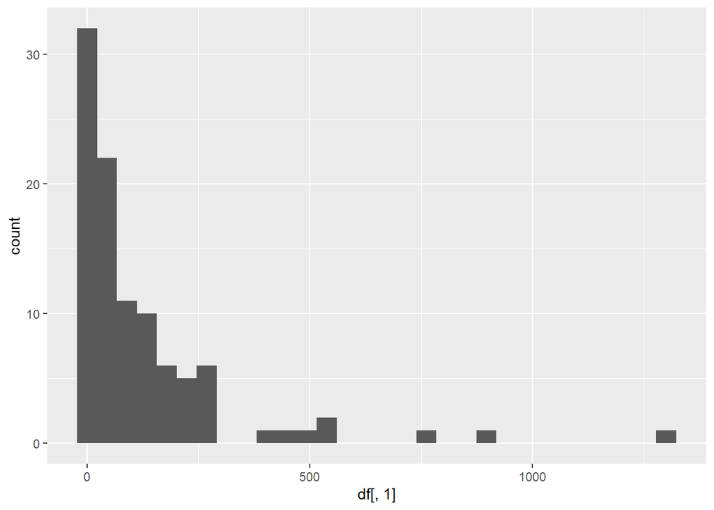

```r
library(ggplot2)
ggplot(df,aes(df[,1]))+
  geom_histogram()
```

```r
# chi square distribution
```

4d. The historgrams for each rows in z, where z is a 3x1000 matrix with the entries following standard normal distribution.

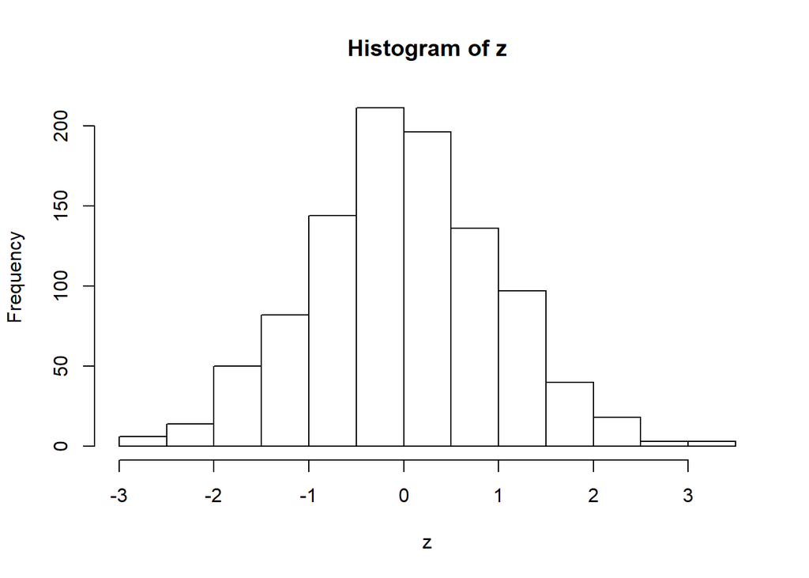

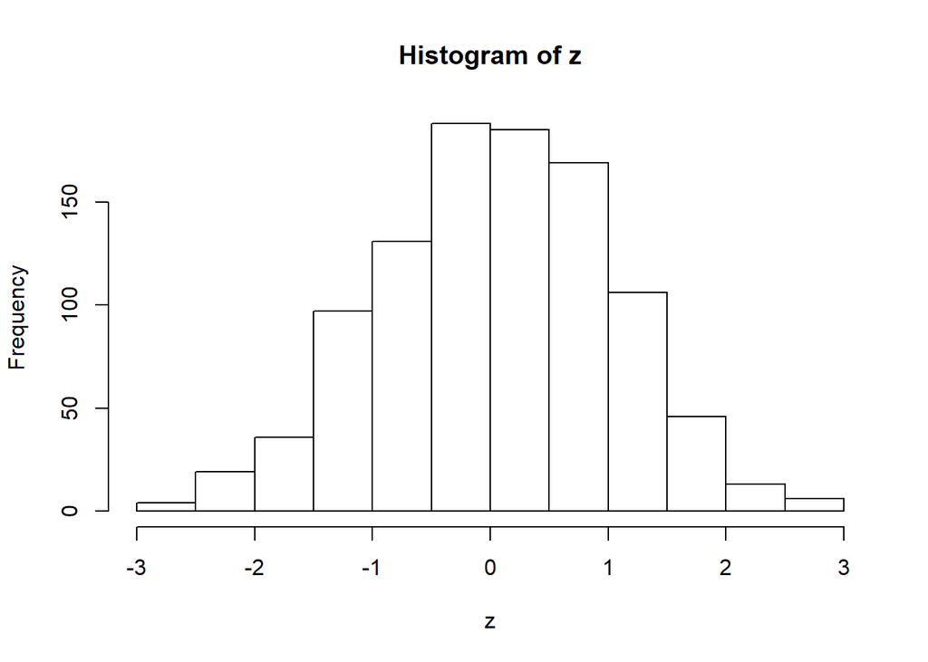

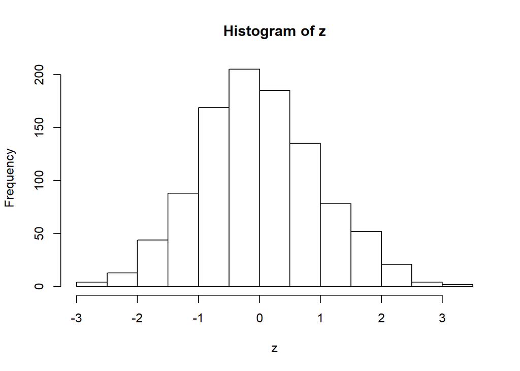

```r
z<- matrix( rnorm(3*1000,mean=0,sd=1), 3, 1000)


z1 <- apply(z, 1, function(z){hist(z)})
```

5. Write a function: input a vector v and a value n output the original vector with its missing data in v being replaced by n. - v could be a numeric or character vector and n could be a number or a string. If there is no missing value, return v and the message There is no missing value.

```r
v  <- c(5,6,7,NA,NA,8)
n=3
 func <- function(v,n) {
 if  (is.numeric(v)) {v[is.na(v)] <- n}
 else if (is.character(v)) {v[is.na(v)] <- n}
else if (sum(is.na(v))==0) print("There is no missing value")
   return(v)
}

func(v,100)
```

```
## [1]   5   6   7 100 100   8
```

6. Write a function: input a numeric vector output the original vector with its missing data being replaced by the mean of the vector. If there is no missing value, return the original vector with the message There is no missing value.

```r
v <- c(1,2,3,NA,NA,NA)

func <- function(v) {
  if (is.numeric(v)) {v[is.na(v)] <- mean(na.omit(v))}
  else if (sum(is.na(v))==0) print("There is no missing value")
  return(v)

}
func(v)
```

```
## [1] 1 2 3 2 2 2
```

7. Write a function: input a character/factor vector output a vector with its missing data being replaced by the mode of the vector. If there is no missing value, return the original vector with the message There is no missing value.

```r
mode<- function(a) {
 z <- na.omit(unique(a))
 z1 <- tabulate(match(a, z)); z[z1 == max(z1) ] }

v <- c('a','b','b','c',NA,NA,NA)

func <- function(v) {
  if (is.character(v)) {v[is.na(v)] <- mode(na.omit(v))}
  else if (sum(is.na(v))==0) print("There is no missing value")
  return(v)

}
func(v)
```

```
## [1] "a" "b" "b" "c" "b" "b" "b"
```

8. Write a function: input a data frame output the data frame with numeric missing values being replaced by the corresponding column mean and categorical missing values being replaced by the corresponding column mode.

```r
df <- read.csv(file="C:\\Users\\student\\Documents\\R\\titanic.csv")
head(df)
```

```
##   PassengerId Survived Pclass
## 1           1        0      3
## 2           2        1      1
## 3           3        1      3
## 4           4        1      1
## 5           5        0      3
## 6           6        0      3
##                                                  Name    Sex Age SibSp
## 1                             Braund, Mr. Owen Harris   male  22     1
## 2 Cumings, Mrs. John Bradley (Florence Briggs Thayer) female  38     1
## 3                              Heikkinen, Miss. Laina female  26     0
## 4        Futrelle, Mrs. Jacques Heath (Lily May Peel) female  35     1
## 5                            Allen, Mr. William Henry   male  35     0
## 6                                    Moran, Mr. James   male  NA     0
##   Parch           Ticket    Fare Cabin Embarked
## 1     0        A/5 21171  7.2500              S
## 2     0         PC 17599 71.2833   C85        C
## 3     0 STON/O2. 3101282  7.9250              S
## 4     0           113803 53.1000  C123        S
## 5     0           373450  8.0500              S
## 6     0           330877  8.4583              Q
```

```r
# I attempted this but could not figure it out (also why 9 and 10 are blank)
```